# ¶ “RENDIMIENTO Y CUALIDADES FÍSICAS DE CADA JUGADOR DE LA LIGA SANTANDER DE ESPAÑA TEMPORADA 2022-2023” ¶

##### Gráfica de Defensa Derecha vs Equipo

```r
C=filter = LALIGA[LALIGA$EQUIPO %in% c("Atletico","Real Madrid","Barcelona","Sevilla","Real Sociedad","Real Betis"),]
C
```

|  | NOMBRE | EQUIPO | EDAD | POSICION | MINUTOS | AMARILLA | DISPAROS | PASES_A | AEREOS_G | CLASIFICACION | DEFENSA | MEDIO | DELANTERO | DEFENSAD | DEFENSAI | DEFENSAC | MEDIOI | MEDIOD | MEDIOC | PARTIDO | APARICIONES |
| --- | --- | --- | --- | --- | --- | --- | --- | --- | --- | --- | --- | --- | --- | --- | --- | --- | --- | --- | --- | --- | --- |
| 2 | Karim Benzema | Real Madrid | 35 | FW | 1306 | 1 | 4.7 | 87.0 | 0.7 | 7.45 | FALSE | FALSE | TRUE | FALSE | FALSE | FALSE | FALSE | FALSE | FALSE | 15 | 15 |
| 6 | Federico Valverde | Real Madrid | 24 | M(CLR) | 1960 | 2 | 2.1 | 88.2 | 0.9 | 7.26 | FALSE | TRUE | FALSE | FALSE | FALSE | FALSE | TRUE | TRUE | TRUE | 22 | 0 |
| 7 | Mikel Merino | Real Sociedad | 26 | M(C) | 1607 | 5 | 1.5 | 76.8 | 3.5 | 7.23 | FALSE | TRUE | FALSE | FALSE | FALSE | FALSE | FALSE | FALSE | TRUE | 18 | 3 |
| 9 | Rodrygo | Real Madrid | 22 | AM(CLR) FW | 1546 | 2 | 2.9 | 89.9 | 0.5 | 7.20 | FALSE | TRUE | TRUE | FALSE | FALSE | FALSE | TRUE | TRUE | TRUE | 16 | 6 |
| 12 | Ousmane Dembélé | Barcelona | 25 | AM(CLR) FW | 1108 | 4 | 2.2 | 84.0 | 0.1 | 7.18 | FALSE | TRUE | TRUE | FALSE | FALSE | FALSE | TRUE | TRUE | TRUE | 14 | 4 |
| 13 | Pape Gueye | Sevilla | 24 | DMC | 433 | 1 | 1.4 | 82.8 | 1.2 | 7.12 | TRUE | FALSE | FALSE | FALSE | FALSE | TRUE | FALSE | FALSE | FALSE | 5 | 5 |
| 17 | Frenkie de Jong | Barcelona | 25 | D(C) DMC | 1693 | 2 | 0.6 | 90.5 | 0.8 | 7.09 | TRUE | FALSE | FALSE | FALSE | FALSE | TRUE | FALSE | FALSE | FALSE | 0 | 0 |
| 21 | Éder Militão | Real Madrid | 25 | D(CR) | 1668 | 3 | 0.8 | 87.9 | 2.0 | 7.06 | TRUE | FALSE | FALSE | TRUE | FALSE | TRUE | FALSE | FALSE | FALSE | 19 | 2 |
| 25 | Raphinha | Barcelona | 26 | AM(LR) FW | 1275 | 4 | 2.0 | 80.6 | 0.3 | 7.03 | FALSE | TRUE | TRUE | FALSE | FALSE | FALSE | TRUE | TRUE | FALSE | 14 | 10 |
| 29 | Brais Méndez | Real Sociedad | 26 | AM(CR) FW | 1837 | 5 | 1.8 | 82.9 | 0.8 | 7.01 | FALSE | TRUE | TRUE | FALSE | FALSE | FALSE | FALSE | TRUE | TRUE | 22 | 2 |

[output cut: 96 more lines]

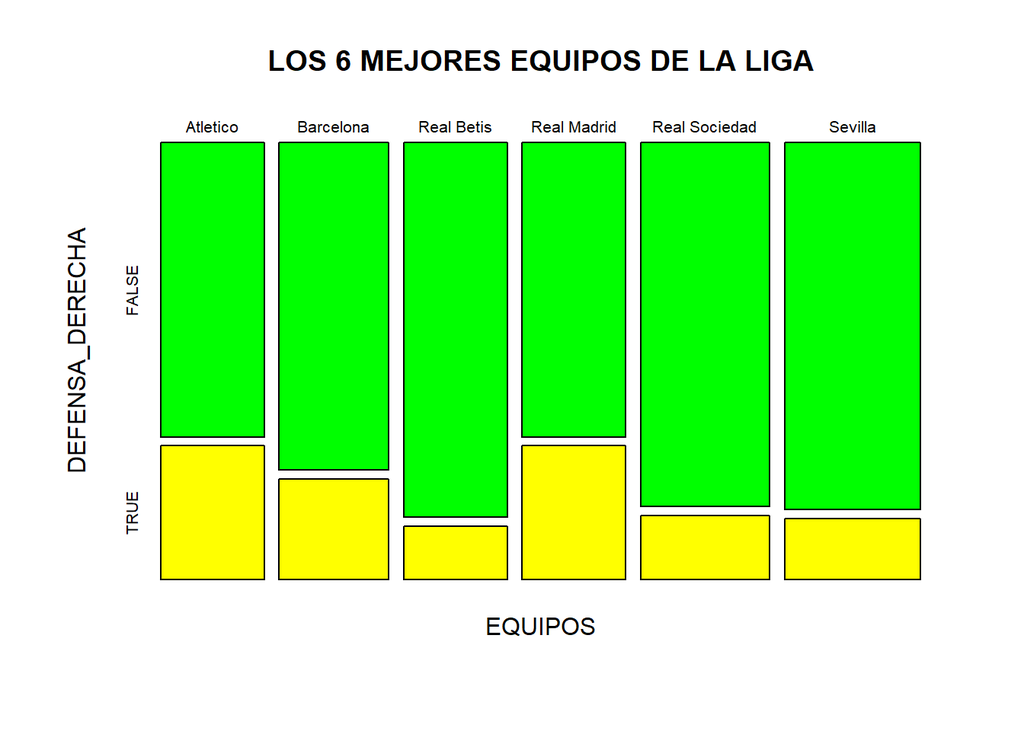

```r
mosaicplot(table(C$EQUIPO, C$DEFENSAD),
           main = "LOS 6 MEJORES EQUIPOS DE LA LIGA",
           xlab = "EQUIPOS",
           ylab = "DEFENSA_DERECHA",
           col = c("green", "yellow"),
           legend = TRUE)
```

- De la gráfica anterior, podemos intuir que el equipo que tiene mas jugadores en la posición de “Defensa derecha”, es el Atlético, seguido por el Real Madrid, Barcelona, Real sociedad, Sevilla y Real Betis en ese orden mencionado. Asimismo, los equipos con mayores jugadores en esta posición son menos afectados cuando ocurren lesiones físicas porque tienen jugadores para poder sustituirlos; de esta manera, no se ven tan afectados para poder disputar duelos posteriores y mantenerse bien toda la jornada.

##### Gráfica de Defensa Izquierda vs Equipo

```r
D=filter = LALIGA[LALIGA$EQUIPO %in% c("Atletico","Real Madrid","Barcelona","Sevilla","Real Sociedad","Real Betis"),]
D
```

|  | NOMBRE | EQUIPO | EDAD | POSICION | MINUTOS | AMARILLA | DISPAROS | PASES_A | AEREOS_G | CLASIFICACION | DEFENSA | MEDIO | DELANTERO | DEFENSAD | DEFENSAI | DEFENSAC | MEDIOI | MEDIOD | MEDIOC | PARTIDO | APARICIONES |
| --- | --- | --- | --- | --- | --- | --- | --- | --- | --- | --- | --- | --- | --- | --- | --- | --- | --- | --- | --- | --- | --- |
| 2 | Karim Benzema | Real Madrid | 35 | FW | 1306 | 1 | 4.7 | 87.0 | 0.7 | 7.45 | FALSE | FALSE | TRUE | FALSE | FALSE | FALSE | FALSE | FALSE | FALSE | 15 | 15 |
| 6 | Federico Valverde | Real Madrid | 24 | M(CLR) | 1960 | 2 | 2.1 | 88.2 | 0.9 | 7.26 | FALSE | TRUE | FALSE | FALSE | FALSE | FALSE | TRUE | TRUE | TRUE | 22 | 0 |
| 7 | Mikel Merino | Real Sociedad | 26 | M(C) | 1607 | 5 | 1.5 | 76.8 | 3.5 | 7.23 | FALSE | TRUE | FALSE | FALSE | FALSE | FALSE | FALSE | FALSE | TRUE | 18 | 3 |
| 9 | Rodrygo | Real Madrid | 22 | AM(CLR) FW | 1546 | 2 | 2.9 | 89.9 | 0.5 | 7.20 | FALSE | TRUE | TRUE | FALSE | FALSE | FALSE | TRUE | TRUE | TRUE | 16 | 6 |
| 12 | Ousmane Dembélé | Barcelona | 25 | AM(CLR) FW | 1108 | 4 | 2.2 | 84.0 | 0.1 | 7.18 | FALSE | TRUE | TRUE | FALSE | FALSE | FALSE | TRUE | TRUE | TRUE | 14 | 4 |
| 13 | Pape Gueye | Sevilla | 24 | DMC | 433 | 1 | 1.4 | 82.8 | 1.2 | 7.12 | TRUE | FALSE | FALSE | FALSE | FALSE | TRUE | FALSE | FALSE | FALSE | 5 | 5 |
| 17 | Frenkie de Jong | Barcelona | 25 | D(C) DMC | 1693 | 2 | 0.6 | 90.5 | 0.8 | 7.09 | TRUE | FALSE | FALSE | FALSE | FALSE | TRUE | FALSE | FALSE | FALSE | 0 | 0 |
| 21 | Éder Militão | Real Madrid | 25 | D(CR) | 1668 | 3 | 0.8 | 87.9 | 2.0 | 7.06 | TRUE | FALSE | FALSE | TRUE | FALSE | TRUE | FALSE | FALSE | FALSE | 19 | 2 |
| 25 | Raphinha | Barcelona | 26 | AM(LR) FW | 1275 | 4 | 2.0 | 80.6 | 0.3 | 7.03 | FALSE | TRUE | TRUE | FALSE | FALSE | FALSE | TRUE | TRUE | FALSE | 14 | 10 |
| 29 | Brais Méndez | Real Sociedad | 26 | AM(CR) FW | 1837 | 5 | 1.8 | 82.9 | 0.8 | 7.01 | FALSE | TRUE | TRUE | FALSE | FALSE | FALSE | FALSE | TRUE | TRUE | 22 | 2 |

[output cut: 96 more lines]

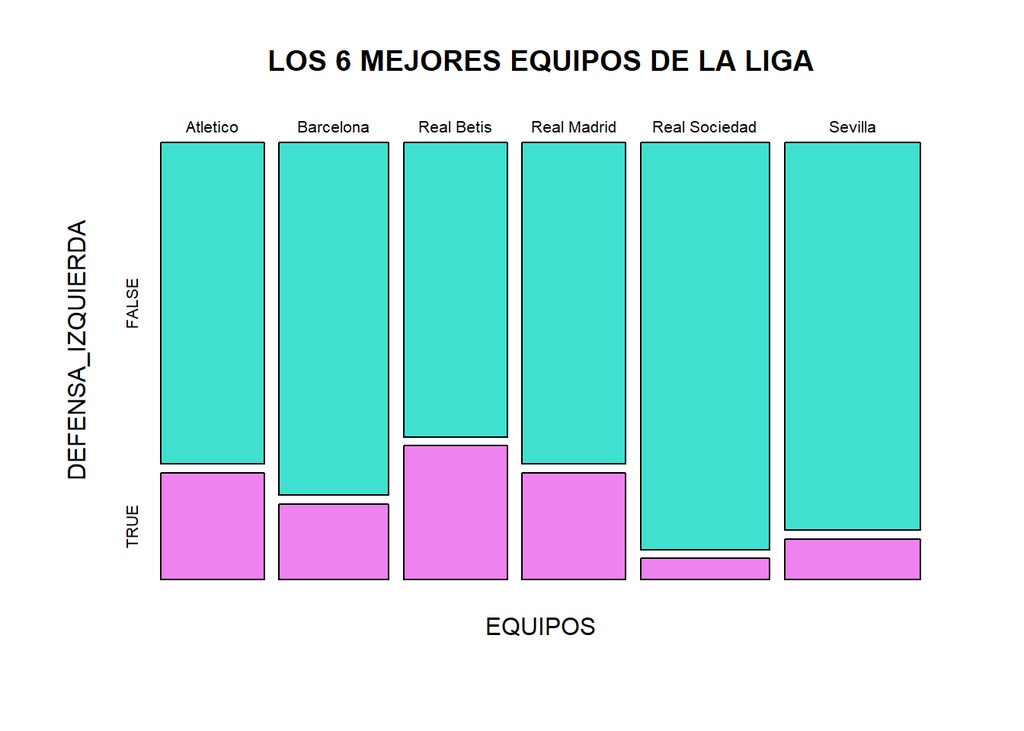

```r
mosaicplot(table(D$EQUIPO, D$DEFENSAI),
           main = "LOS 6 MEJORES EQUIPOS DE LA LIGA",
           xlab = "EQUIPOS",
           ylab = "DEFENSA_IZQUIERDA",
           col = c("turquoise", "violet"),
           legend = TRUE)
```

- De acuerdo a los gráficos mostrados podemos concluir que el Real Betis es el equipo que tiene más jugadores en la posición de defensa izquierda(lateral izquierdo), esto es muy beneficioso para el equipo porque cuando un jugador se lesiona ellos tienen la posibilidad de reemplazarlo con otro jugador alternativo; por lo cual, el equipo no se ve tan afectado pudiendo centrarse en el torneo sin tener una baja significativa de un jugador. En cambio, la Real Sociedad si tendrá perdidas significativas en lo que respecta a la jornada.

##### Gráfico de Defensa Central vs Equipo

```r
E=filter = LALIGA[LALIGA$EQUIPO %in% c("Atletico","Real Madrid","Barcelona","Sevilla","Real Sociedad","Real Betis"),]
E
```

|  | NOMBRE | EQUIPO | EDAD | POSICION | MINUTOS | AMARILLA | DISPAROS | PASES_A | AEREOS_G | CLASIFICACION | DEFENSA | MEDIO | DELANTERO | DEFENSAD | DEFENSAI | DEFENSAC | MEDIOI | MEDIOD | MEDIOC | PARTIDO | APARICIONES |
| --- | --- | --- | --- | --- | --- | --- | --- | --- | --- | --- | --- | --- | --- | --- | --- | --- | --- | --- | --- | --- | --- |
| 2 | Karim Benzema | Real Madrid | 35 | FW | 1306 | 1 | 4.7 | 87.0 | 0.7 | 7.45 | FALSE | FALSE | TRUE | FALSE | FALSE | FALSE | FALSE | FALSE | FALSE | 15 | 15 |
| 6 | Federico Valverde | Real Madrid | 24 | M(CLR) | 1960 | 2 | 2.1 | 88.2 | 0.9 | 7.26 | FALSE | TRUE | FALSE | FALSE | FALSE | FALSE | TRUE | TRUE | TRUE | 22 | 0 |
| 7 | Mikel Merino | Real Sociedad | 26 | M(C) | 1607 | 5 | 1.5 | 76.8 | 3.5 | 7.23 | FALSE | TRUE | FALSE | FALSE | FALSE | FALSE | FALSE | FALSE | TRUE | 18 | 3 |
| 9 | Rodrygo | Real Madrid | 22 | AM(CLR) FW | 1546 | 2 | 2.9 | 89.9 | 0.5 | 7.20 | FALSE | TRUE | TRUE | FALSE | FALSE | FALSE | TRUE | TRUE | TRUE | 16 | 6 |
| 12 | Ousmane Dembélé | Barcelona | 25 | AM(CLR) FW | 1108 | 4 | 2.2 | 84.0 | 0.1 | 7.18 | FALSE | TRUE | TRUE | FALSE | FALSE | FALSE | TRUE | TRUE | TRUE | 14 | 4 |
| 13 | Pape Gueye | Sevilla | 24 | DMC | 433 | 1 | 1.4 | 82.8 | 1.2 | 7.12 | TRUE | FALSE | FALSE | FALSE | FALSE | TRUE | FALSE | FALSE | FALSE | 5 | 5 |
| 17 | Frenkie de Jong | Barcelona | 25 | D(C) DMC | 1693 | 2 | 0.6 | 90.5 | 0.8 | 7.09 | TRUE | FALSE | FALSE | FALSE | FALSE | TRUE | FALSE | FALSE | FALSE | 0 | 0 |
| 21 | Éder Militão | Real Madrid | 25 | D(CR) | 1668 | 3 | 0.8 | 87.9 | 2.0 | 7.06 | TRUE | FALSE | FALSE | TRUE | FALSE | TRUE | FALSE | FALSE | FALSE | 19 | 2 |
| 25 | Raphinha | Barcelona | 26 | AM(LR) FW | 1275 | 4 | 2.0 | 80.6 | 0.3 | 7.03 | FALSE | TRUE | TRUE | FALSE | FALSE | FALSE | TRUE | TRUE | FALSE | 14 | 10 |
| 29 | Brais Méndez | Real Sociedad | 26 | AM(CR) FW | 1837 | 5 | 1.8 | 82.9 | 0.8 | 7.01 | FALSE | TRUE | TRUE | FALSE | FALSE | FALSE | FALSE | TRUE | TRUE | 22 | 2 |

[output cut: 96 more lines]

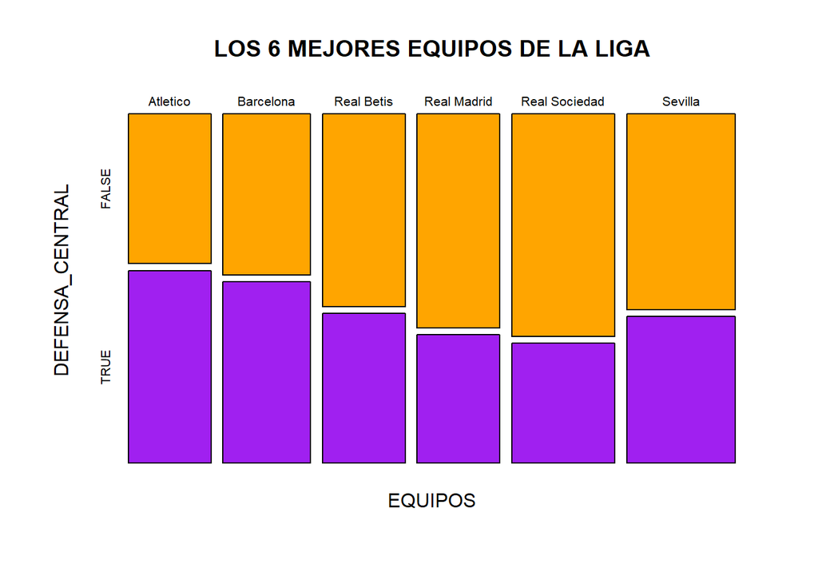

```r
mosaicplot(table(E$EQUIPO, E$DEFENSAC),
           main = "LOS 6 MEJORES EQUIPOS DE LA LIGA",
           xlab = "EQUIPOS",
           ylab = "DEFENSA_CENTRAL",
           col = c("orange", "purple"),
           legend = TRUE)
```

##### Gráfico de Medio-campista Izquierdo vs Equipo

```r
F=filter = LALIGA[LALIGA$EQUIPO %in% c("Atletico","Real Madrid","Barcelona","Sevilla","Real Sociedad","Real Betis"),]
F
```

|  | NOMBRE | EQUIPO | EDAD | POSICION | MINUTOS | AMARILLA | DISPAROS | PASES_A | AEREOS_G | CLASIFICACION | DEFENSA | MEDIO | DELANTERO | DEFENSAD | DEFENSAI | DEFENSAC | MEDIOI | MEDIOD | MEDIOC | PARTIDO | APARICIONES |
| --- | --- | --- | --- | --- | --- | --- | --- | --- | --- | --- | --- | --- | --- | --- | --- | --- | --- | --- | --- | --- | --- |
| 2 | Karim Benzema | Real Madrid | 35 | FW | 1306 | 1 | 4.7 | 87.0 | 0.7 | 7.45 | FALSE | FALSE | TRUE | FALSE | FALSE | FALSE | FALSE | FALSE | FALSE | 15 | 15 |
| 6 | Federico Valverde | Real Madrid | 24 | M(CLR) | 1960 | 2 | 2.1 | 88.2 | 0.9 | 7.26 | FALSE | TRUE | FALSE | FALSE | FALSE | FALSE | TRUE | TRUE | TRUE | 22 | 0 |
| 7 | Mikel Merino | Real Sociedad | 26 | M(C) | 1607 | 5 | 1.5 | 76.8 | 3.5 | 7.23 | FALSE | TRUE | FALSE | FALSE | FALSE | FALSE | FALSE | FALSE | TRUE | 18 | 3 |
| 9 | Rodrygo | Real Madrid | 22 | AM(CLR) FW | 1546 | 2 | 2.9 | 89.9 | 0.5 | 7.20 | FALSE | TRUE | TRUE | FALSE | FALSE | FALSE | TRUE | TRUE | TRUE | 16 | 6 |
| 12 | Ousmane Dembélé | Barcelona | 25 | AM(CLR) FW | 1108 | 4 | 2.2 | 84.0 | 0.1 | 7.18 | FALSE | TRUE | TRUE | FALSE | FALSE | FALSE | TRUE | TRUE | TRUE | 14 | 4 |
| 13 | Pape Gueye | Sevilla | 24 | DMC | 433 | 1 | 1.4 | 82.8 | 1.2 | 7.12 | TRUE | FALSE | FALSE | FALSE | FALSE | TRUE | FALSE | FALSE | FALSE | 5 | 5 |
| 17 | Frenkie de Jong | Barcelona | 25 | D(C) DMC | 1693 | 2 | 0.6 | 90.5 | 0.8 | 7.09 | TRUE | FALSE | FALSE | FALSE | FALSE | TRUE | FALSE | FALSE | FALSE | 0 | 0 |
| 21 | Éder Militão | Real Madrid | 25 | D(CR) | 1668 | 3 | 0.8 | 87.9 | 2.0 | 7.06 | TRUE | FALSE | FALSE | TRUE | FALSE | TRUE | FALSE | FALSE | FALSE | 19 | 2 |
| 25 | Raphinha | Barcelona | 26 | AM(LR) FW | 1275 | 4 | 2.0 | 80.6 | 0.3 | 7.03 | FALSE | TRUE | TRUE | FALSE | FALSE | FALSE | TRUE | TRUE | FALSE | 14 | 10 |
| 29 | Brais Méndez | Real Sociedad | 26 | AM(CR) FW | 1837 | 5 | 1.8 | 82.9 | 0.8 | 7.01 | FALSE | TRUE | TRUE | FALSE | FALSE | FALSE | FALSE | TRUE | TRUE | 22 | 2 |

[output cut: 96 more lines]

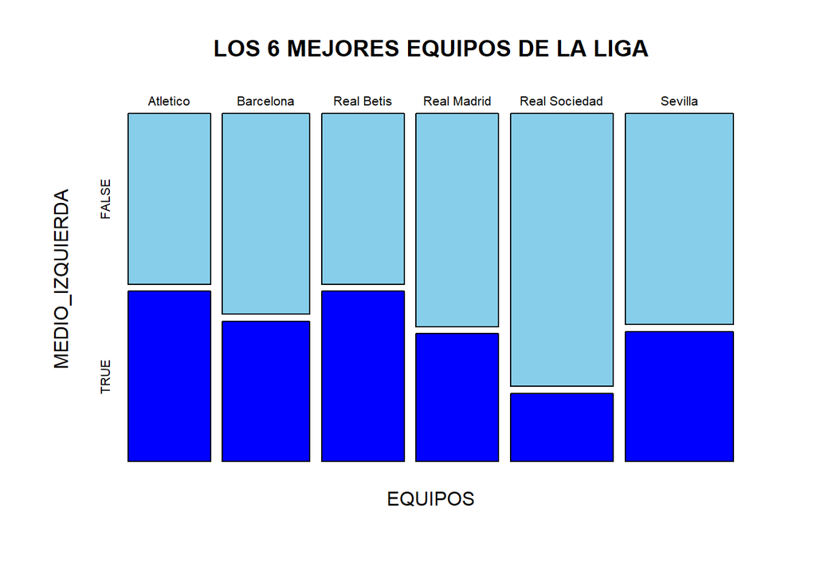

```r
mosaicplot(table(F$EQUIPO, F$MEDIOI),
           main = "LOS 6 MEJORES EQUIPOS DE LA LIGA",
           xlab = "EQUIPOS",
           ylab = "MEDIO_IZQUIERDA",
           col = c("skyblue", "blue"),
           legend = TRUE)
```

##### Gráfico de Medio-campista Derecho vs Equipo

```r
G=filter = LALIGA[LALIGA$EQUIPO %in% c("Atletico","Real Madrid","Barcelona","Sevilla","Real Sociedad","Real Betis"),]
G
```

|  | NOMBRE | EQUIPO | EDAD | POSICION | MINUTOS | AMARILLA | DISPAROS | PASES_A | AEREOS_G | CLASIFICACION | DEFENSA | MEDIO | DELANTERO | DEFENSAD | DEFENSAI | DEFENSAC | MEDIOI | MEDIOD | MEDIOC | PARTIDO | APARICIONES |
| --- | --- | --- | --- | --- | --- | --- | --- | --- | --- | --- | --- | --- | --- | --- | --- | --- | --- | --- | --- | --- | --- |
| 2 | Karim Benzema | Real Madrid | 35 | FW | 1306 | 1 | 4.7 | 87.0 | 0.7 | 7.45 | FALSE | FALSE | TRUE | FALSE | FALSE | FALSE | FALSE | FALSE | FALSE | 15 | 15 |
| 6 | Federico Valverde | Real Madrid | 24 | M(CLR) | 1960 | 2 | 2.1 | 88.2 | 0.9 | 7.26 | FALSE | TRUE | FALSE | FALSE | FALSE | FALSE | TRUE | TRUE | TRUE | 22 | 0 |
| 7 | Mikel Merino | Real Sociedad | 26 | M(C) | 1607 | 5 | 1.5 | 76.8 | 3.5 | 7.23 | FALSE | TRUE | FALSE | FALSE | FALSE | FALSE | FALSE | FALSE | TRUE | 18 | 3 |
| 9 | Rodrygo | Real Madrid | 22 | AM(CLR) FW | 1546 | 2 | 2.9 | 89.9 | 0.5 | 7.20 | FALSE | TRUE | TRUE | FALSE | FALSE | FALSE | TRUE | TRUE | TRUE | 16 | 6 |
| 12 | Ousmane Dembélé | Barcelona | 25 | AM(CLR) FW | 1108 | 4 | 2.2 | 84.0 | 0.1 | 7.18 | FALSE | TRUE | TRUE | FALSE | FALSE | FALSE | TRUE | TRUE | TRUE | 14 | 4 |
| 13 | Pape Gueye | Sevilla | 24 | DMC | 433 | 1 | 1.4 | 82.8 | 1.2 | 7.12 | TRUE | FALSE | FALSE | FALSE | FALSE | TRUE | FALSE | FALSE | FALSE | 5 | 5 |
| 17 | Frenkie de Jong | Barcelona | 25 | D(C) DMC | 1693 | 2 | 0.6 | 90.5 | 0.8 | 7.09 | TRUE | FALSE | FALSE | FALSE | FALSE | TRUE | FALSE | FALSE | FALSE | 0 | 0 |
| 21 | Éder Militão | Real Madrid | 25 | D(CR) | 1668 | 3 | 0.8 | 87.9 | 2.0 | 7.06 | TRUE | FALSE | FALSE | TRUE | FALSE | TRUE | FALSE | FALSE | FALSE | 19 | 2 |
| 25 | Raphinha | Barcelona | 26 | AM(LR) FW | 1275 | 4 | 2.0 | 80.6 | 0.3 | 7.03 | FALSE | TRUE | TRUE | FALSE | FALSE | FALSE | TRUE | TRUE | FALSE | 14 | 10 |
| 29 | Brais Méndez | Real Sociedad | 26 | AM(CR) FW | 1837 | 5 | 1.8 | 82.9 | 0.8 | 7.01 | FALSE | TRUE | TRUE | FALSE | FALSE | FALSE | FALSE | TRUE | TRUE | 22 | 2 |

[output cut: 96 more lines]

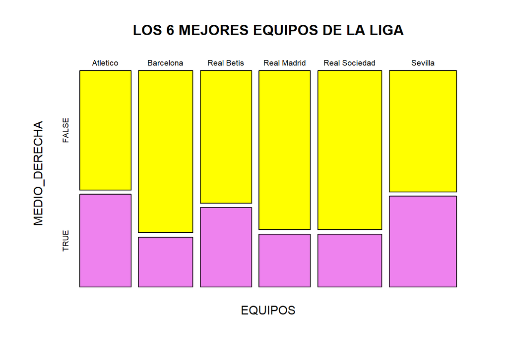

```r
mosaicplot(table(G$EQUIPO, G$MEDIOD ),
           main = "LOS 6 MEJORES EQUIPOS DE LA LIGA",
           xlab = "EQUIPOS",
           ylab = "MEDIO_DERECHA",
           col = c("yellow", "violet"),
           legend = TRUE)
```

- El rol de los jugadores de la posición medio-campista tanto derecho como izquierdo es muy importante para tener el control y dominio de la posición del balón. En este caso en ambas gráficas observamos que el atlético es el equipo con más jugadores en la posición de medio central derecha, también el Sevilla y el Real Betis lo que les favorece a tener un mayor rendimiento en la posición mostradas, además que alguno dellos sufra lesiones no sería muy perjudicado.

##### Gráfico de Medio-campista Central vs Equipo

```r
H=filter = LALIGA[LALIGA$EQUIPO %in% c("Atletico","Real Madrid","Barcelona","Sevilla","Real Sociedad","Real Betis"),]
H
```

|  | NOMBRE | EQUIPO | EDAD | POSICION | MINUTOS | AMARILLA | DISPAROS | PASES_A | AEREOS_G | CLASIFICACION | DEFENSA | MEDIO | DELANTERO | DEFENSAD | DEFENSAI | DEFENSAC | MEDIOI | MEDIOD | MEDIOC | PARTIDO | APARICIONES |
| --- | --- | --- | --- | --- | --- | --- | --- | --- | --- | --- | --- | --- | --- | --- | --- | --- | --- | --- | --- | --- | --- |
| 2 | Karim Benzema | Real Madrid | 35 | FW | 1306 | 1 | 4.7 | 87.0 | 0.7 | 7.45 | FALSE | FALSE | TRUE | FALSE | FALSE | FALSE | FALSE | FALSE | FALSE | 15 | 15 |
| 6 | Federico Valverde | Real Madrid | 24 | M(CLR) | 1960 | 2 | 2.1 | 88.2 | 0.9 | 7.26 | FALSE | TRUE | FALSE | FALSE | FALSE | FALSE | TRUE | TRUE | TRUE | 22 | 0 |
| 7 | Mikel Merino | Real Sociedad | 26 | M(C) | 1607 | 5 | 1.5 | 76.8 | 3.5 | 7.23 | FALSE | TRUE | FALSE | FALSE | FALSE | FALSE | FALSE | FALSE | TRUE | 18 | 3 |
| 9 | Rodrygo | Real Madrid | 22 | AM(CLR) FW | 1546 | 2 | 2.9 | 89.9 | 0.5 | 7.20 | FALSE | TRUE | TRUE | FALSE | FALSE | FALSE | TRUE | TRUE | TRUE | 16 | 6 |
| 12 | Ousmane Dembélé | Barcelona | 25 | AM(CLR) FW | 1108 | 4 | 2.2 | 84.0 | 0.1 | 7.18 | FALSE | TRUE | TRUE | FALSE | FALSE | FALSE | TRUE | TRUE | TRUE | 14 | 4 |
| 13 | Pape Gueye | Sevilla | 24 | DMC | 433 | 1 | 1.4 | 82.8 | 1.2 | 7.12 | TRUE | FALSE | FALSE | FALSE | FALSE | TRUE | FALSE | FALSE | FALSE | 5 | 5 |
| 17 | Frenkie de Jong | Barcelona | 25 | D(C) DMC | 1693 | 2 | 0.6 | 90.5 | 0.8 | 7.09 | TRUE | FALSE | FALSE | FALSE | FALSE | TRUE | FALSE | FALSE | FALSE | 0 | 0 |
| 21 | Éder Militão | Real Madrid | 25 | D(CR) | 1668 | 3 | 0.8 | 87.9 | 2.0 | 7.06 | TRUE | FALSE | FALSE | TRUE | FALSE | TRUE | FALSE | FALSE | FALSE | 19 | 2 |
| 25 | Raphinha | Barcelona | 26 | AM(LR) FW | 1275 | 4 | 2.0 | 80.6 | 0.3 | 7.03 | FALSE | TRUE | TRUE | FALSE | FALSE | FALSE | TRUE | TRUE | FALSE | 14 | 10 |
| 29 | Brais Méndez | Real Sociedad | 26 | AM(CR) FW | 1837 | 5 | 1.8 | 82.9 | 0.8 | 7.01 | FALSE | TRUE | TRUE | FALSE | FALSE | FALSE | FALSE | TRUE | TRUE | 22 | 2 |

[output cut: 96 more lines]

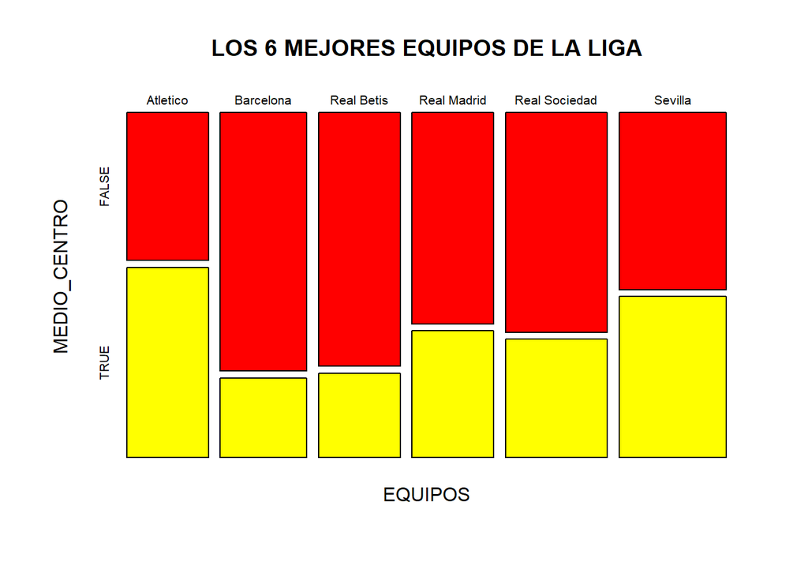

```r
mosaicplot(table(H$EQUIPO, H$MEDIOC),
           main = "LOS 6 MEJORES EQUIPOS DE LA LIGA",
           xlab = "EQUIPOS",
           ylab = "MEDIO_CENTRO",
           col = c("red", "yellow"),
           legend = TRUE)
```

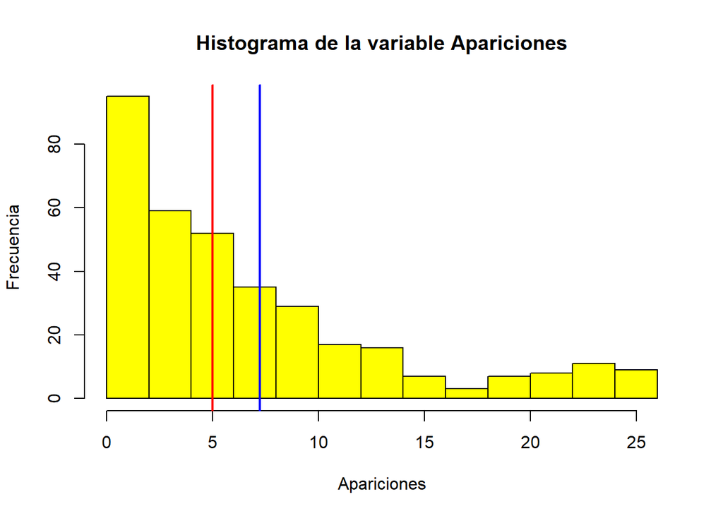

```r
hist(LALIGA$APARICIONES,main="Histograma de la variable Apariciones",col = "yellow", xlab = "Apariciones",ylab = "Frecuencia")
abline(v=median(LALIGA$APARICIONES),col="red",lwd=2)
abline(v=mean(LALIGA$APARICIONES),col="blue",lwd=2)
legend(200,0.012,legend = c("Mediana","Media"),lwd=2,col = c("red","blue"))
```

- La variable Apariciones es una variable de tipo numérica; por lo cual, usamos un gráfico de barras para poder interpretar mejor su información. Asimismo, para estimar el rendimiento físico de un jugador es necesario analizar el numero de apariciones que realizo durante la jornada, ya que esto nos da un alcance que a mayor apariciones dentro del campo el jugador esta mas óptimo y entrenado en sus condiciones físicas.

##### Gráfico de disperión de Apariciones vs Edad

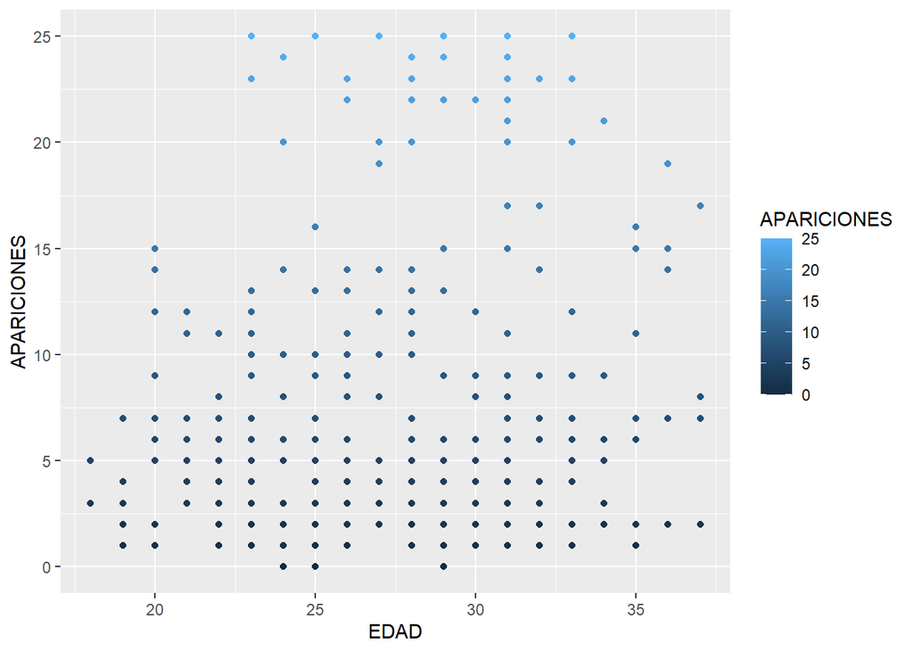

```r
LALIGA %>% ggplot(., aes(EDAD, APARICIONES, colour=APARICIONES)) + geom_point()
```

Para conocer al jugador con mayor número de apariciones utilizamos la función max()

```r
MAX = max(LALIGA$APARICIONES)
MAX
```

```
## [1] 25
```

Procedemos a filtrar aquellos jugadores que tuvieron 25 apariciones que fue la máximo número de apariciones

```r
filter(LALIGA,LALIGA$APARICIONES==MAX)
```

| NOMBRE | EQUIPO | EDAD | POSICION | MINUTOS | AMARILLA | DISPAROS | PASES_A | AEREOS_G | CLASIFICACION | DEFENSA | MEDIO | DELANTERO | DEFENSAD | DEFENSAI | DEFENSAC | MEDIOI | MEDIOD | MEDIOC | PARTIDO | APARICIONES |
| --- | --- | --- | --- | --- | --- | --- | --- | --- | --- | --- | --- | --- | --- | --- | --- | --- | --- | --- | --- | --- |
| Aleix García | Girona | 25 | DMC | 2148 | 1 | 1.2 | 89.3 | 0.5 | 7.19 | TRUE | FALSE | FALSE | FALSE | FALSE | TRUE | FALSE | FALSE | FALSE | 25 | 25 |
| Sergi Darder | Espanyol | 29 | M(CL) | 2225 | 2 | 1.0 | 77.7 | 0.2 | 7.10 | FALSE | TRUE | FALSE | FALSE | FALSE | FALSE | TRUE | FALSE | TRUE | 25 | 25 |
| Enes Ünal | Getafe | 25 | FW | 2190 | 4 | 2.5 | 63.6 | 3.9 | 7.08 | FALSE | FALSE | TRUE | FALSE | FALSE | FALSE | FALSE | FALSE | FALSE | 25 | 25 |
| Daniel Parejo | Villarreal | 33 | M(C) | 2209 | 3 | 0.7 | 89.7 | 0.4 | 7.03 | FALSE | TRUE | FALSE | FALSE | FALSE | FALSE | FALSE | FALSE | TRUE | 25 | 25 |
| Joseph Aidoo | Celta Vigo | 27 | D(C) | 2234 | 4 | 0.4 | 85.2 | 1.7 | 6.71 | TRUE | FALSE | FALSE | FALSE | FALSE | TRUE | FALSE | FALSE | FALSE | 25 | 25 |
| Fran García | Rayo Vallecano | 23 | D(L) | 2239 | 1 | 0.8 | 82.4 | 0.2 | 6.67 | TRUE | FALSE | FALSE | FALSE | TRUE | FALSE | FALSE | FALSE | FALSE | 25 | 25 |
| Iván Balliu | Rayo Vallecano | 31 | D(R) M(R) | 2183 | 5 | 0.2 | 80.8 | 0.8 | 6.53 | TRUE | TRUE | FALSE | TRUE | FALSE | FALSE | FALSE | TRUE | FALSE | 25 | 25 |
| Sergio Akieme | Almeria | 25 | D(L) | 2118 | 5 | 0.9 | 80.7 | 0.6 | 6.49 | TRUE | FALSE | FALSE | FALSE | TRUE | FALSE | FALSE | FALSE | FALSE | 25 | 25 |
| Borja Mayoral | Getafe | 25 | FW | 2055 | 4 | 1.6 | 77.5 | 1.0 | 6.49 | FALSE | FALSE | TRUE | FALSE | FALSE | FALSE | FALSE | FALSE | FALSE | 25 | 25 |

##### Gráfica de disperisón de Minutos jugador vs Edad

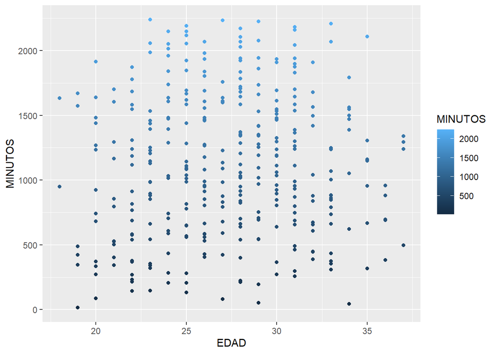

```r
LALIGA %>% ggplot(., aes(EDAD, MINUTOS, colour=MINUTOS)) + geom_point()
```

- La gráfica nos resume los minutos jugados de un jugador en toda la temporada de la liga respecto a su edad, es decir, nos muestra la cantidad de minutos que jugo en un partido y cual es su edad, donde nos podemos dar cuenta que los jugadores que tienen un rango de 20 a 30, fueron los que jugaron más.Asimismo, con esta interpretación podemos concluir que para que un jugador juegue una mayor cantidad de minutos durante la temporada, tuvo que estar muy bien física y mentalmente, es decir, su rendimiento físico estuvo en óptimas condiciones.

##### Gráfica de dispersión de Apariciones y minutos

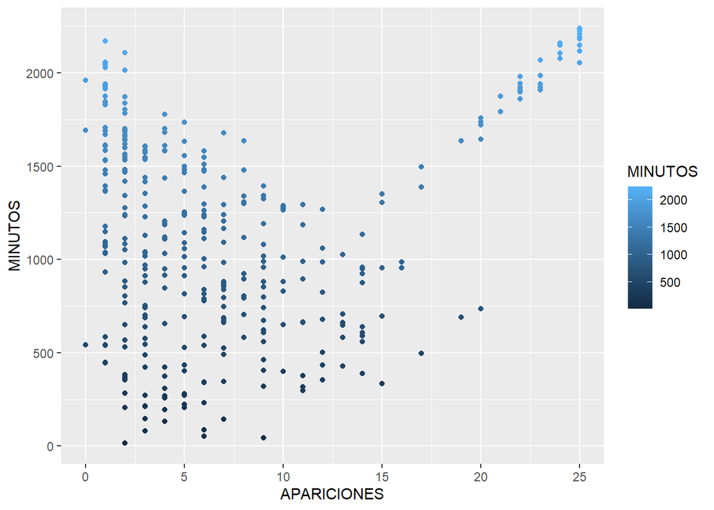

```r
LALIGA %>% ggplot(., aes(APARICIONES, MINUTOS, colour=MINUTOS)) + geom_point()
```

- En la gráfica se puede observar la relación que existe entre la cantidad de apariciones y minutos de cada una de los jugadores, donde se puede ver que la mayoría de ellos tuvo pocas apariciones

Conocido los minutos de manera general procedemos a buscar la máxima cantidad de minutos jugados de los jugadores

```r
MAXMIN = max(LALIGA$MINUTOS)
MAXMIN
```

```
## [1] 2239
```

Una vez encontrado la cantidad de minutos procedemos a filtrar al jugador con el mayor número de minutos jugados

```r
filter(LALIGA,LALIGA$MINUTOS==MAXMIN)
```

| NOMBRE | EQUIPO | EDAD | POSICION | MINUTOS | AMARILLA | DISPAROS | PASES_A | AEREOS_G | CLASIFICACION | DEFENSA | MEDIO | DELANTERO | DEFENSAD | DEFENSAI | DEFENSAC | MEDIOI | MEDIOD | MEDIOC | PARTIDO | APARICIONES |
| --- | --- | --- | --- | --- | --- | --- | --- | --- | --- | --- | --- | --- | --- | --- | --- | --- | --- | --- | --- | --- |
| Fran García | Rayo Vallecano | 23 | D(L) | 2239 | 1 | 0.8 | 82.4 | 0.2 | 6.67 | TRUE | FALSE | FALSE | FALSE | TRUE | FALSE | FALSE | FALSE | FALSE | 25 | 25 |

De esta manera podemos concluir que Fran García es el jugador con mayor rendimiento físico de LaLiga Santander de España, es decir, este jugador en toda la temporada un mejor aporte para su equipo.

#### Analizando la variable PARTIDO

```r
summary(LALIGA$PARTIDO) # Detalles de la variable PARTIDO
```

```
##    Min. 1st Qu.  Median    Mean 3rd Qu.    Max.
##    0.00    7.00   12.50   12.65   18.00   25.00
```

```r
unique(LALIGA$PARTIDO) # Se visualiza la variable PARTIDO sin repeticiones.
```

```
##  [1] 15 22 18 21 16 25 14  5  6  0 19 23 24 12 17 20 10 11  3 13  8  9  4  7  2
## [26]  1
```

```r
LALIGA %>% count(PARTIDO) # Se visualiza la variable
```

| PARTIDO | n |
| --- | --- |
| 0 | 5 |
| 1 | 4 |
| 2 | 14 |
| 3 | 14 |
| 4 | 9 |
| 5 | 15 |
| 6 | 13 |
| 7 | 15 |
| 8 | 21 |
| 9 | 13 |

[output cut: 16 more lines]

##### Histograma de Partidos jugados en la temporada 2022-2023

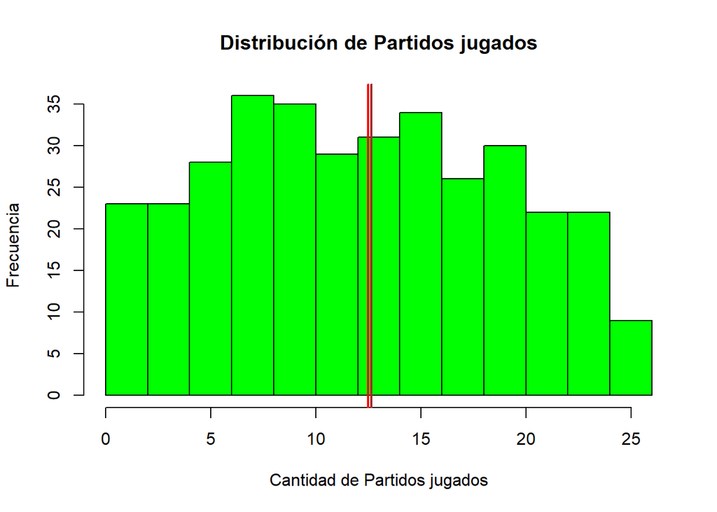

```r
hist(LALIGA$PARTIDO,main="Distribución de Partidos jugados",col = "green", xlab = "Cantidad de Partidos jugados",ylab = "Frecuencia")
abline(v=median(LALIGA$PARTIDO),col="red",lwd=2)
abline(v=mean(LALIGA$PARTIDO),col="brown",lwd=2)
legend(200,0.012,legend = c("Mediana","Media"),lwd=2,col = c("red","brown"))
```

#### Analizando la variable PASES_A(Pases acertados)

```r
summary(LALIGA$PASES_A) # Detalles de la variable PASES_A
```

```
##    Min. 1st Qu.  Median    Mean 3rd Qu.    Max.
##   44.40   76.78   81.30   80.34   85.50   93.80
```

```r
unique(LALIGA$PASES_A) # Se visualiza la variable PASES_A sin repeticiones.
```

```
##   [1] 87.0 88.2 76.8 61.6 89.9 89.3 84.0 82.8 76.6 77.7 90.5 63.6 81.4 79.2 87.9
##  [16] 79.1 80.6 89.7 79.7 58.1 82.9 93.5 88.3 89.1 73.4 88.4 81.9 91.0 86.8 93.6
##  [31] 87.1 88.0 81.0 82.1 63.2 70.4 80.8 88.1 92.2 71.9 77.0 77.4 88.7 92.0 80.3
##  [46] 78.7 86.7 84.5 90.2 76.3 85.7 91.6 86.2 80.5 73.1 85.3 78.8 79.9 90.9 88.8
##  [61] 85.0 86.9 85.1 72.6 91.5 92.9 70.0 60.1 83.4 89.4 83.3 81.2 74.8 85.2 77.1
##  [76] 81.8 84.8 58.4 85.5 86.3 83.8 64.5 79.4 84.9 77.9 77.2 82.4 92.1 72.3 64.2
##  [91] 88.9 87.7 84.7 92.5 78.2 86.5 83.5 87.5 69.3 77.6 73.9 82.3 89.2 79.5 82.2
## [106] 65.5 81.6 83.0 82.7 80.0 78.6 80.9 83.6 93.2 84.3 76.1 76.5 92.3 91.8 63.1
## [121] 83.2 79.6 69.4 74.7 75.7 77.5 83.7 84.2 86.6 78.0 74.9 70.7 63.8 82.5 72.5
## [136] 85.6 73.0 81.3 86.1 63.9 66.3 67.8 80.7 81.7 75.2 82.6 67.9 80.1 90.0 84.6
## [151] 76.0 78.4 82.0 73.8 75.6 79.8 73.2 73.5 75.0 80.2 90.8 87.4 84.4 70.8 71.3
## [166] 83.1 79.3 70.1 65.6 81.5 52.5 71.1 64.1 71.8 67.4 87.6 62.7 93.8 88.5 78.9
## [181] 70.2 73.6 58.8 81.1 68.9 61.1 76.7 89.0 55.4 64.7 72.0 44.4 68.2 72.2
```

```r
LALIGA %>% count(PASES_A) # Se visualiza la variable
```

| PASES_A | n |
| --- | --- |
| 44.4 | 1 |
| 52.5 | 1 |
| 55.4 | 1 |
| 58.1 | 1 |
| 58.4 | 2 |
| 58.8 | 1 |
| 60.1 | 1 |
| 61.1 | 1 |
| 61.6 | 1 |
| 62.7 | 1 |

[output cut: 184 more lines]

##### Histograma de pases acertados en porcentajes de los jugadores

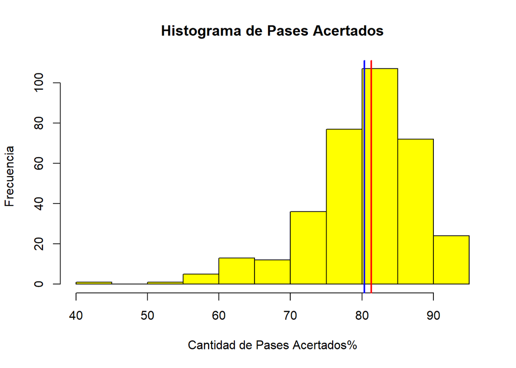

```r
hist(LALIGA$PASES_A,main="Histograma de Pases Acertados",col = "yellow", xlab = "Cantidad de Pases Acertados%",ylab = "Frecuencia")
abline(v=median(LALIGA$PASES_A),col="red",lwd=2)
abline(v=mean(LALIGA$PASES_A),col="blue",lwd=2)
legend(200,0.012,legend = c("Mediana","Media"),lwd=2,col = c("red","blue"))
```

#### Analizando la variable AEREOS_G(Duelos aéreos ganados)

```r
summary(LALIGA$AEREOS_G) # Detalles de la variable AEREOS_G
```

```
##    Min. 1st Qu.  Median    Mean 3rd Qu.    Max.
##  0.1000  0.4000  0.7000  0.9356  1.3000  5.6000
```

```r
unique(LALIGA$AEREOS_G) # Se visualiza la variable AEREOS_G sin repeticiones.
```

```
##  [1] 0.7 0.9 3.5 5.6 0.5 0.1 1.2 1.7 0.2 0.8 3.9 2.0 1.0 0.3 0.4 1.3 1.1 0.6 1.9
## [20] 2.1 1.4 1.5 2.6 2.9 1.8 2.2 2.5 2.8 1.6 3.0 2.3 2.4
```

```r
LALIGA %>% count(AEREOS_G) # Se visualiza la variable
```

| AEREOS_G | n |
| --- | --- |
| 0.1 | 23 |
| 0.2 | 24 |
| 0.3 | 30 |
| 0.4 | 29 |
| 0.5 | 24 |
| 0.6 | 24 |
| 0.7 | 23 |
| 0.8 | 22 |
| 0.9 | 20 |
| 1.0 | 14 |

[output cut: 22 more lines]

##### Histograma de los duelos aéreos ganados en un rango de 1 a 6

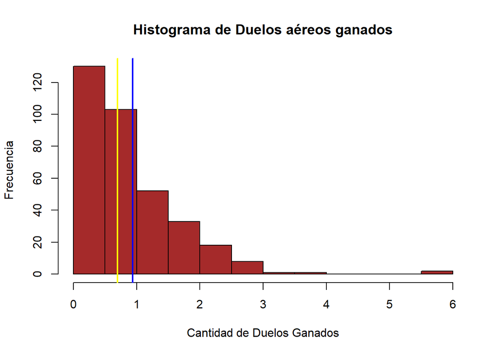

```r
hist(LALIGA$AEREOS_G,main="Histograma de Duelos aéreos ganados",col = "brown", xlab = "Cantidad de Duelos Ganados",ylab = "Frecuencia")
abline(v=median(LALIGA$AEREOS_G),col="yellow",lwd=2)
abline(v=mean(LALIGA$AEREOS_G),col="blue",lwd=2)
legend(200,0.012,legend = c("Mediana","Media"),lwd=2,col = c("yellow","blue"))
```

#### Para un mejor análisis relacionamos la cantidad de partido, los duelos ganados y pases acertados, para así conocer quien fue el mejor jugador de la temporada

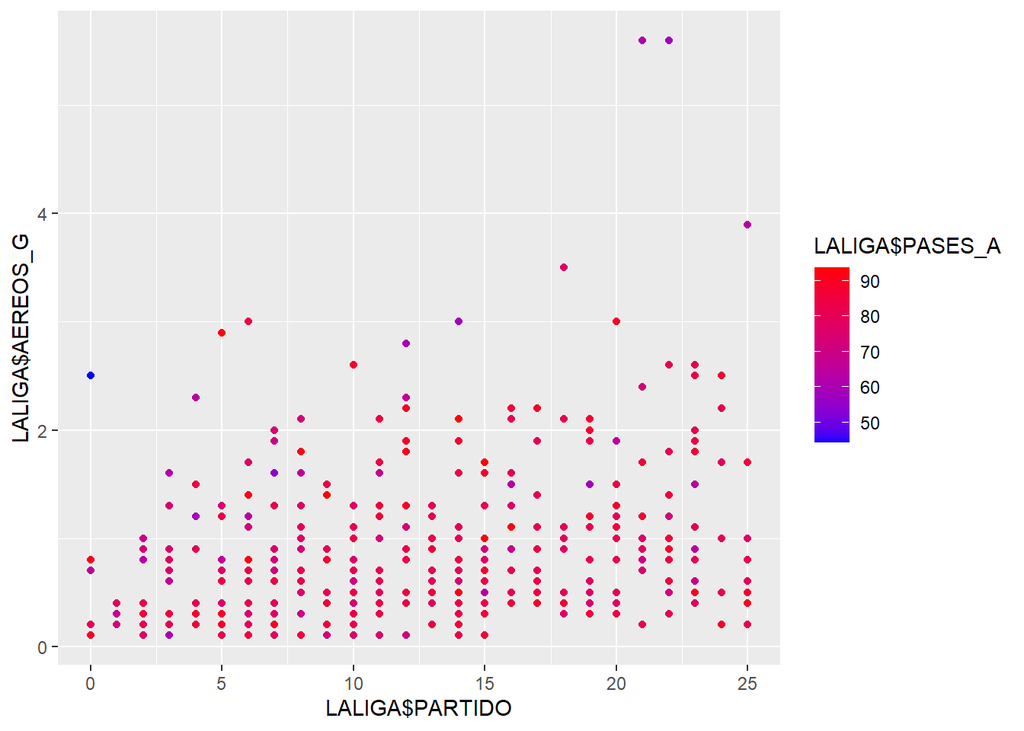

```r
ggplot(data = data.frame(LALIGA$PARTIDO, LALIGA$AEREOS_G, LALIGA$PASES_A), aes(x = LALIGA$PARTIDO, y = LALIGA$AEREOS_G, colour=LALIGA$PASES_A)) +
  geom_point() + scale_color_gradient(low = "blue", high = "red")
```

- Esta gráfica nos muestra de manera general cuales fueron los jugadores que tuvieron más partidos, más duelos ganados y la mayor cantidad de pases acertados,además de la gráfica podemos interpretar que los que tienen mayor pases acertados y duelos aéreos ganados, respecto a los partidos jugados son los mejores jugadores; los cuales tuvieron un mejor desempeño dando una fiabilidad al momento de mantener la posición del balón para el equipo, que es un factor muy importante para que puedan tener el dominio del juego.
- De la gráfica nos podemos dar cuenta de forma general que los jugadores que tuvieron un buen rendimiento físico podemos considerarlo como el mejor jugador de la temporada es aquel que tuvo un más de 20 partidos jugados, un porcentaje de pases acertados mayor a 80 y un rango de más de 2 en duelos aéreos ganados.
- Con este análisis procedemos a buscar al jugador con las cualidades ya mencionadas.

```r
RENDIMIENTO = filter(LALIGA,LALIGA$AEREOS_G>2,LALIGA$PASES_A>80,LALIGA$PARTIDO>20)
RENDIMIENTO
```

| NOMBRE | EQUIPO | EDAD | POSICION | MINUTOS | AMARILLA | DISPAROS | PASES_A | AEREOS_G | CLASIFICACION | DEFENSA | MEDIO | DELANTERO | DEFENSAD | DEFENSAI | DEFENSAC | MEDIOI | MEDIOD | MEDIOC | PARTIDO | APARICIONES |
| --- | --- | --- | --- | --- | --- | --- | --- | --- | --- | --- | --- | --- | --- | --- | --- | --- | --- | --- | --- | --- |
| David García | Osasuna | 29 | D(C) | 1942 | 7 | 0.5 | 80.8 | 2.6 | 6.86 | TRUE | FALSE | FALSE | FALSE | FALSE | TRUE | FALSE | FALSE | FALSE | 22 | 22 |
| Vinicius Souza | Espanyol | 23 | DMC | 1985 | 5 | 0.3 | 80.6 | 2.6 | 6.85 | TRUE | FALSE | FALSE | FALSE | FALSE | TRUE | FALSE | FALSE | FALSE | 23 | 23 |
| Antonio Raíllo | Mallorca | 31 | D(C) | 2160 | 8 | 0.4 | 85.1 | 2.5 | 6.74 | TRUE | FALSE | FALSE | FALSE | FALSE | TRUE | FALSE | FALSE | FALSE | 24 | 24 |
| Alejandro Catena | Rayo Vallecano | 28 | D(C) | 2070 | 7 | 0.4 | 83.3 | 2.5 | 6.72 | TRUE | FALSE | FALSE | FALSE | FALSE | TRUE | FALSE | FALSE | FALSE | 23 | 23 |
| Santiago Bueno | Girona | 24 | D(C) | 2148 | 4 | 0.5 | 86.5 | 2.2 | 6.59 | TRUE | FALSE | FALSE | FALSE | FALSE | TRUE | FALSE | FALSE | FALSE | 24 | 24 |
| Rodrigo Ely | Almeria | 29 | D(C) | 2078 | 4 | 0.6 | 80.2 | 2.2 | 6.43 | TRUE | FALSE | FALSE | FALSE | FALSE | TRUE | FALSE | FALSE | FALSE | 24 | 24 |

#### Gráfica de contorno de densidad de Pases Acertados vs Duelos Aéreos ganados

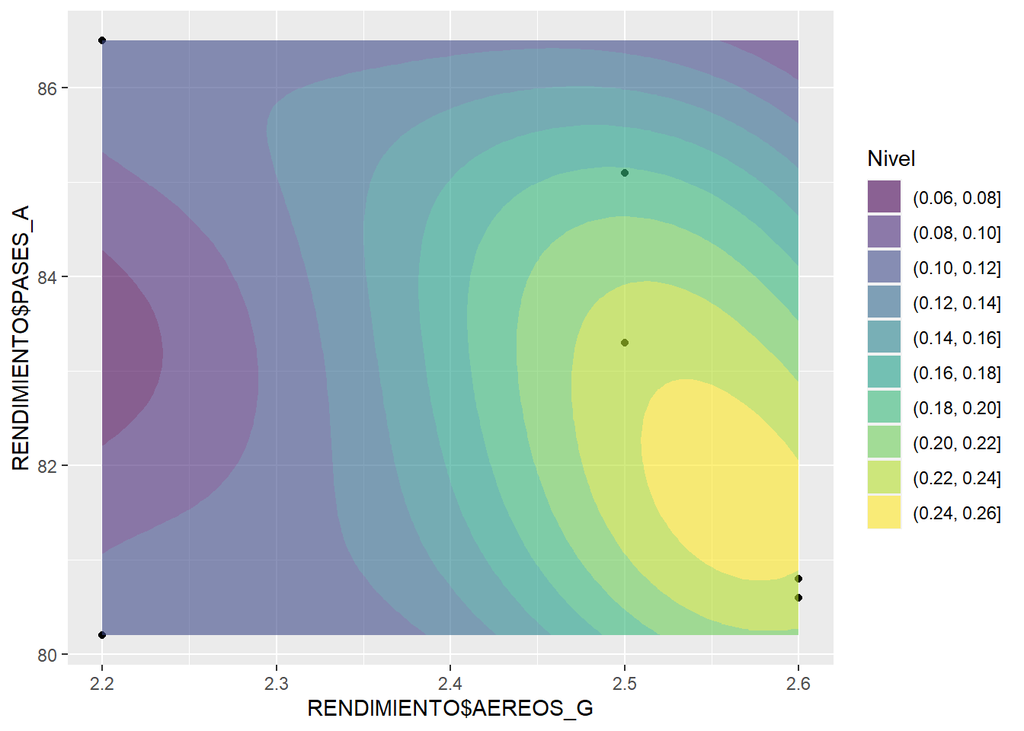

```r
ggplot(RENDIMIENTO, aes(x = RENDIMIENTO$AEREOS_G, y = RENDIMIENTO$PASES_A)) +
  geom_point() +
  geom_density_2d_filled(alpha=0.6)+
  guides(fill = guide_legend(title = "Nivel"))
```

- De la gráfica podemos observar la relación entre los pases acertados y los duelos aéreos ganados de los 6 jugadores que tuvieron buen desempeño,además, analizando detenidamente podemos darnos que un jugador da un porcentaje de pases acertados relativamente alto y posee en duelos aéreos ganado un nivel no tan bajo, por ende este sería el jugador que estimamos como el mejor jugador de la temporada, dentro de sus cualidades encontramos que tiene en duelos ganados un nivel de 2.5 y un porcentaje mayor a 84% en pases acertados.
- Procedemos a buscar al jugador:

```r
filter(RENDIMIENTO,RENDIMIENTO$PASES_A>84,RENDIMIENTO$AEREOS_G==2.5)
```

| NOMBRE | EQUIPO | EDAD | POSICION | MINUTOS | AMARILLA | DISPAROS | PASES_A | AEREOS_G | CLASIFICACION | DEFENSA | MEDIO | DELANTERO | DEFENSAD | DEFENSAI | DEFENSAC | MEDIOI | MEDIOD | MEDIOC | PARTIDO | APARICIONES |
| --- | --- | --- | --- | --- | --- | --- | --- | --- | --- | --- | --- | --- | --- | --- | --- | --- | --- | --- | --- | --- |
| Antonio Raíllo | Mallorca | 31 | D(C) | 2160 | 8 | 0.4 | 85.1 | 2.5 | 6.74 | TRUE | FALSE | FALSE | FALSE | FALSE | TRUE | FALSE | FALSE | FALSE | 24 | 24 |

- De esta manera nosotros estimamos que el mejor jugador de la temporada tomando en cuenta los porcentajes de pases acertados, los duelos aéreos ganados y los partidos que jugó es el jugador Antonio Raíllo, quien pertenece al equipo del Mallorca, este tiene 31 años y juega en la posición de Defensa Central, cabe recalcar que la edad no es un factor influyente en los jugadores.

#### Analizando la variable AMARILLA(Tarjetas amarillas de los jugadores)

```r
summary(LALIGA$AMARILLA) # detalles de la variable AMARILLAS
```

```
##    Min. 1st Qu.  Median    Mean 3rd Qu.    Max.
##    1.00    2.00    3.00    3.31    4.00   10.00
```

```r
unique(LALIGA$AMARILLA) # Se visualiza la variable AMARILLAS sin repeticiones.
```

```
##  [1]  1  2  5  3  4  6  7  9  8 10
```

```r
LALIGA %>% count(AMARILLA) # Se visualiza la variable
```

| AMARILLA | n |
| --- | --- |
| 1 | 78 |
| 2 | 66 |
| 3 | 57 |
| 4 | 64 |
| 5 | 32 |
| 6 | 20 |
| 7 | 19 |
| 8 | 7 |
| 9 | 4 |
| 10 | 1 |

```r
var(LALIGA$AMARILLA,na.rm=T) # Variación
```

```
## [1] 4.001391
```

```r
sd(LALIGA$AMARILLA,na.rm=T)  # Desviación estándar
```

```
## [1] 2.000348
```

```r
CV_MIN<-(sd(LALIGA$AMARILLA,na.rm=T)/mean(LALIGA$MINUTOS,na.rm=T))*100 # coeficiente de variación.
CV_MIN
```

```
## [1] 0.1775706
```

##### Histograma de la cantidad de Tarjetas amarillas en toda la temporada

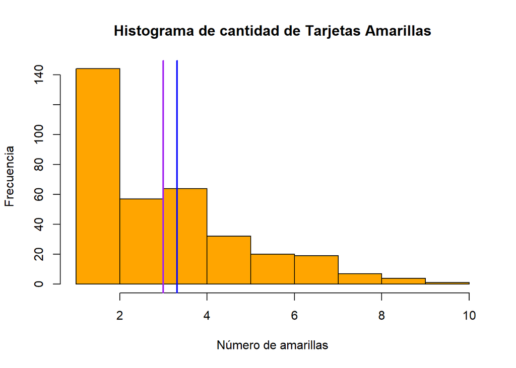

```r
hist(LALIGA$AMARILLA,main="Histograma de cantidad de Tarjetas Amarillas",col = "orange", xlab = "Número de amarillas",ylab = "Frecuencia")
abline(v=median(LALIGA$AMARILLA),col="purple",lwd=2)
abline(v=mean(LALIGA$AMARILLA),col="blue",lwd=2)
legend(200,0.012,legend = c("Mediana","Media"),lwd=2,col = c("purple","blue"))
```

- En este gráfico podemos observar la mayor frecuencia de amarillas se da de en los intervalos de [0,4], quiere decir, que los jugadores de la liga santander tienden a cometer faltas de infracción leve(tajeta amarillas) solo de 0 a 4 veces mayormente.

##### Histograma de Equipo vs acumulación de tarjetas amarillas por equipos

```r
data_de_comparacion <- data.frame(EQUIPO=LALIGA$EQUIPO, AMARILLA=LALIGA$AMARILLA)
data_de_comparacion
```

| EQUIPO | AMARILLA |
| --- | --- |
| Real Madrid | 1 |
| Real Madrid | 2 |
| Real Sociedad | 5 |
| Espanyol | 3 |
| Real Madrid | 2 |
| Girona | 1 |
| Barcelona | 4 |
| Sevilla | 1 |
| Cadiz | 2 |
| Espanyol | 2 |

[output cut: 338 more lines]

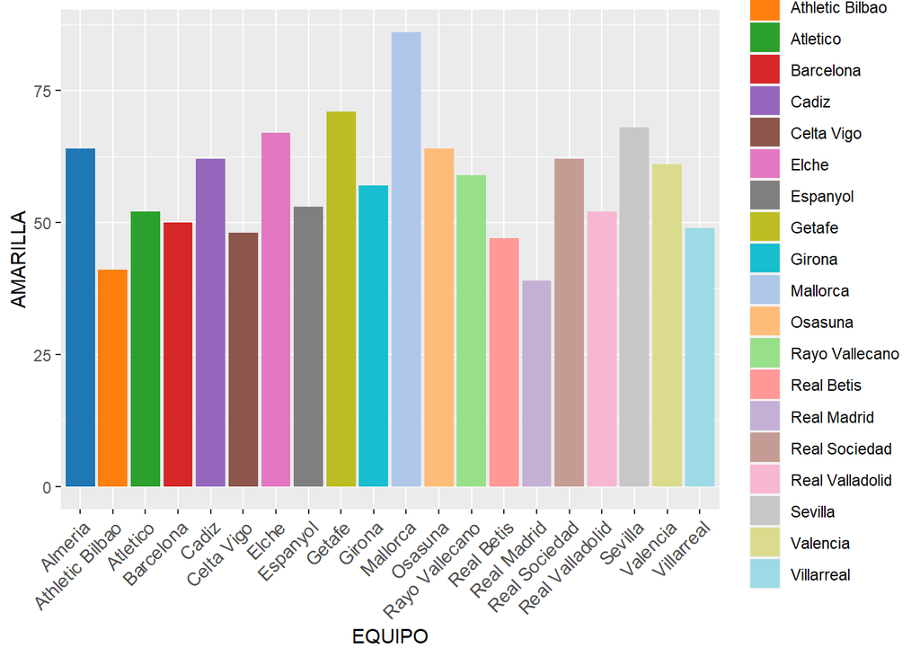

```r
colores <- c("#1f77b4", "#ff7f0e", "#2ca02c", "#d62728", "#9467bd",
             "#8c564b", "#e377c2", "#7f7f7f", "#bcbd22", "#17becf",
             "#aec7e8", "#ffbb78", "#98df8a", "#ff9896", "#c5b0d5",
             "#c49c94", "#f7b6d2", "#c7c7c7", "#dbdb8d", "#9edae5")

ggplot(data_de_comparacion, aes(x = EQUIPO, y = AMARILLA, fill=EQUIPO)) +
  geom_bar(stat = "identity")+
  theme(axis.text.x = element_text(angle = 45, hjust = 1)) +
  theme(axis.text.x = element_text(size = 10))+
  scale_fill_manual(values = colores)
```

- En el gráfico se puede determinar con mayor facilidad que equipo cometió mayores faltas y menores faltas, por ende, el equipo con mayor cantidad de tarjetas amarillas durante la temporada fue el Mayorca y el equipo que cometió menos infracciones fue el Real Madrid.

##### Gráfico de dispersión de Equipos vs Edad

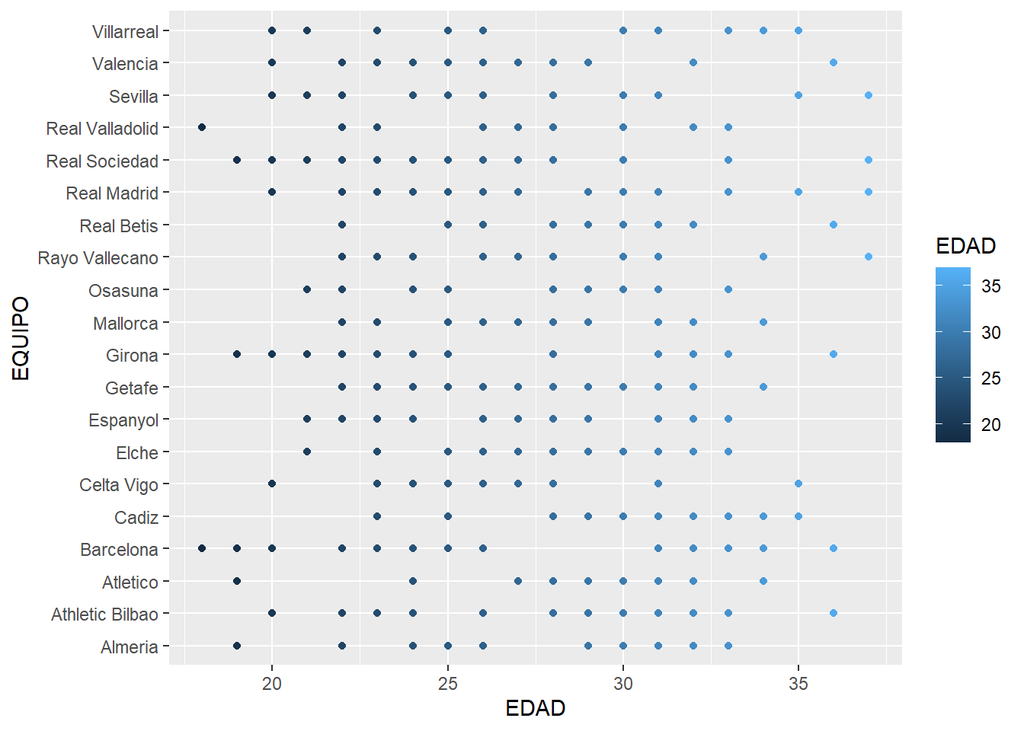

```r
LALIGA %>% ggplot(., aes(EDAD, EQUIPO, colour=EDAD)) + geom_point()
```

##### Gráfica de dispersión de Equipo vs cantidad de tajetas amarillas

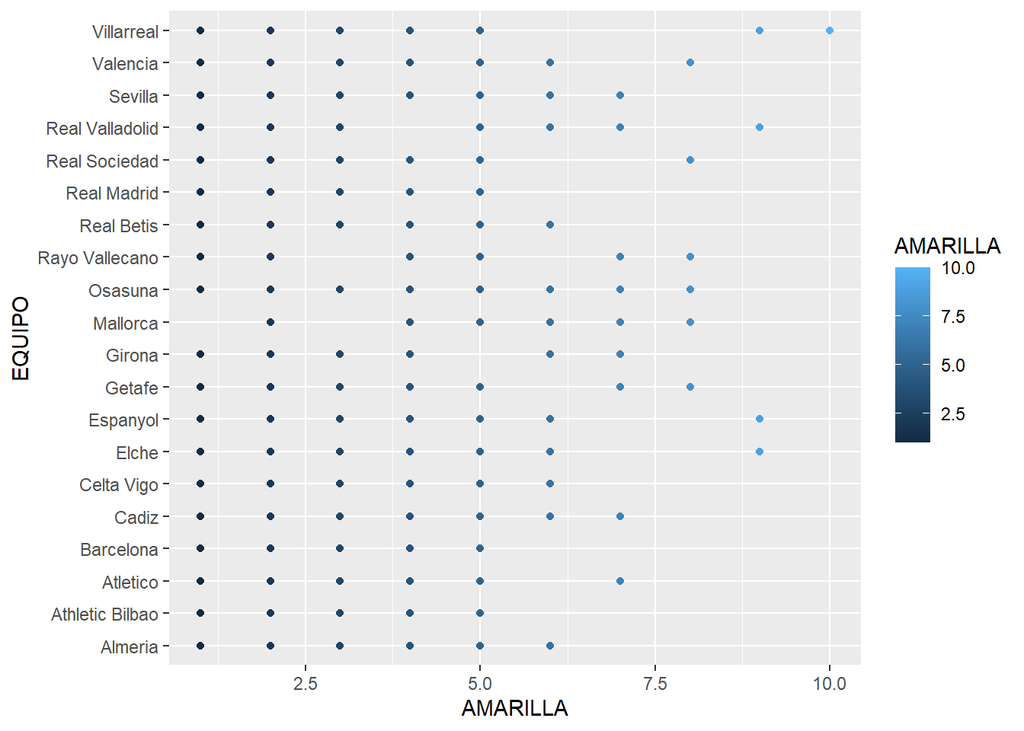

```r
LALIGA %>% ggplot(., aes(AMARILLA, EQUIPO, colour=AMARILLA)) + geom_point()
```

- Básicamente, al analizar la variable equipo con la variable de amarillas acumuladas, podemos estimar que equipo comete el mayor números de faltas por temporada. Asimismo, podemos estimar al equipo que comete el menor numero de faltas, con esta interpretación también podemos sesgar a los jugadores que mas faltas cometen por cada equipo.

Para saber al jugador que recibió más tarjetas amarillas durante la temporada utilizamos la función max()

```r
MAX_A = max(LALIGA$AMARILLA)
```

Una vez encontrado la mayor cantidad de tarjetas amarillas lo filtramos

```r
filter(LALIGA,LALIGA$AMARILLA==MAX_A)
```

| NOMBRE | EQUIPO | EDAD | POSICION | MINUTOS | AMARILLA | DISPAROS | PASES_A | AEREOS_G | CLASIFICACION | DEFENSA | MEDIO | DELANTERO | DEFENSAD | DEFENSAI | DEFENSAC | MEDIOI | MEDIOD | MEDIOC | PARTIDO | APARICIONES |
| --- | --- | --- | --- | --- | --- | --- | --- | --- | --- | --- | --- | --- | --- | --- | --- | --- | --- | --- | --- | --- |
| Álex Baena | Villarreal | 21 | AM(CL) | 1293 | 10 | 1.7 | 81 | 0.1 | 6.58 | FALSE | TRUE | FALSE | FALSE | FALSE | FALSE | TRUE | FALSE | TRUE | 12 | 11 |

De esta manera concluimos que el jugador con mayor infracción en tarjetas amarillas es Álex Baena quien pertenece al equipo del Villarreal con un total de 10 tarjetas.

Asimismo procedemos como dato adicional a filtrar al jugador o los jugadores con menor número de tarjetas amarillas

```r
MIN_A=min(LALIGA$AMARILLA)
filter(LALIGA,LALIGA$AMARILLA==MIN_A)
```

| NOMBRE | EQUIPO | EDAD | POSICION | MINUTOS | AMARILLA | DISPAROS | PASES_A | AEREOS_G | CLASIFICACION | DEFENSA | MEDIO | DELANTERO | DEFENSAD | DEFENSAI | DEFENSAC | MEDIOI | MEDIOD | MEDIOC | PARTIDO | APARICIONES |
| --- | --- | --- | --- | --- | --- | --- | --- | --- | --- | --- | --- | --- | --- | --- | --- | --- | --- | --- | --- | --- |
| Karim Benzema | Real Madrid | 35 | FW | 1306 | 1 | 4.7 | 87.0 | 0.7 | 7.45 | FALSE | FALSE | TRUE | FALSE | FALSE | FALSE | FALSE | FALSE | FALSE | 15 | 15 |
| Aleix García | Girona | 25 | DMC | 2148 | 1 | 1.2 | 89.3 | 0.5 | 7.19 | TRUE | FALSE | FALSE | FALSE | FALSE | TRUE | FALSE | FALSE | FALSE | 25 | 25 |
| Pape Gueye | Sevilla | 24 | DMC | 433 | 1 | 1.4 | 82.8 | 1.2 | 7.12 | TRUE | FALSE | FALSE | FALSE | FALSE | TRUE | FALSE | FALSE | FALSE | 5 | 5 |
| Aurélien Tchouaméni | Real Madrid | 23 | DMC | 1252 | 1 | 1.1 | 93.5 | 1.7 | 6.99 | TRUE | FALSE | FALSE | FALSE | FALSE | TRUE | FALSE | FALSE | FALSE | 15 | 5 |
| Jules Koundé | Barcelona | 24 | D(CR) | 1393 | 1 | 0.4 | 89.1 | 1.3 | 6.97 | TRUE | FALSE | FALSE | TRUE | FALSE | TRUE | FALSE | FALSE | FALSE | 16 | 1 |
| Loïc Badé | Sevilla | 22 | D(C) | 538 | 1 | 0.1 | 91.0 | 1.4 | 6.84 | TRUE | FALSE | FALSE | FALSE | FALSE | TRUE | FALSE | FALSE | FALSE | 6 | 1 |
| Álex Moreno | Real Betis | 29 | D(L) M(L) | 1350 | 1 | 0.9 | 77.4 | 0.6 | 6.84 | TRUE | TRUE | FALSE | FALSE | TRUE | FALSE | TRUE | FALSE | FALSE | 15 | 15 |
| Nico Williams | Athletic Bilbao | 20 | AM(LR) | 1916 | 1 | 2.0 | 78.7 | 0.4 | 6.81 | FALSE | TRUE | FALSE | FALSE | FALSE | FALSE | TRUE | TRUE | FALSE | 23 | 1 |
| Samuel Chukwueze | Villarreal | 23 | AM(CR) | 1394 | 1 | 1.3 | 77.7 | 0.3 | 6.81 | FALSE | TRUE | FALSE | FALSE | FALSE | FALSE | FALSE | TRUE | TRUE | 15 | 9 |
| Anuar Tuhami | Real Valladolid | 28 | AM(C) | 212 | 1 | 1.0 | 76.3 | 0.7 | 6.80 | FALSE | TRUE | FALSE | FALSE | FALSE | FALSE | FALSE | FALSE | TRUE | 3 | 3 |

[output cut: 68 more lines]